# Руководство по шаблонам lernOS

Ваше собственное руководство по lernOS в спринте

Симон Дюкерт

Версия 0.1 (09.12.2021)

# 1 О lernOS

lernOS - это метод самоорганизации для людей, живущих и работающих в 21 веке. Чтобы быть успешным сегодня, необходимо постоянно учиться, организовывать и развиваться. Никто другой не несет ответственности за этот процесс. Вы должны позаботиться об этом сами (самонаправленное обучение в течение всей жизни).

Руководства lernOS лицензированы на условиях [Creative Commons Attribution 4.0 International](https://creativecommons.org/licenses/by/4.0/deed.de) (CC BY 4.0):

**Вы можете:**

- **Делиться** - воспроизводить и распространять материал в любом формате или на любом носителе.
- **Редактирование** - ремикширование, изменение и развитие материала в любых целях, даже коммерческих.

**При следующих условиях:**

- **Атрибуция** - Вы должны предоставить соответствующие уведомления об авторском праве и правах, включить ссылку на лицензию и указать, были ли внесены какие-либо изменения. Эти сведения могут быть раскрыты любым разумным способом, но не таким, который создает впечатление, что лицензиар особенно благосклонен к вам или вашему использованию.
- **Никаких дополнительных ограничений** - Вы не можете использовать какие-либо дополнительные оговорки или технические процедуры, которые юридически запрещают другим делать все, что разрешено лицензией.

# 2 Основы

## 2.1 Основная идея руководств lernOS

Руководство lernOS помогает учащимся достичь своей собственной цели обучения в рамках учебного спринта (3 месяца) через заранее определенный путь обучения. Учащиеся учатся самостоятельно, в учебном тандеме или в учебном кругу (4-5 человек). Время, необходимое для спринта, не должно превышать двух часов в неделю. Учебная задача может быть поставлена в одной из этих областей или в их комбинации:

- **MINDSET** - выработка определенного отношения
- **SKILLSET** - обучение какому-либо навыку
- **НАБОР ИНСТРУМЕНТОВ** - овладение инструментом или методом

Руководство по lernOS всегда лицензируется на условиях [Creative Commons Attribution 4.0 International License](https://creativecommons.org/licenses/by/4.0/deed.de) (CC BY). Лицензия также распространяется на изображения, используемые в руководстве. Все материалы должны быть доступны в редактируемых исходных форматах (для изображений, например, PNG и SVG). Содержание руководства lernOS управляется как [репозиторий на GitHub](https://github.com) для обеспечения открытого доступа и легкого повторного использования.

[figure not shown]

Открытая лицензия Creative Commons Attribution 4.0 International

Это позволяет открыто получать доступ к содержимому lernOS, использовать, изменять и распространять его в любых целях (включая коммерческие приложения). Однако продукты и услуги не должны иметь в своем названии термин "lernOS". Этот подход сопоставим с браузером Chromium и продуктами на его основе - [Google Chrome](https://de.wikipedia.org/wiki/Google_Chrome), [Microsoft Edge](https://de.wikipedia.org/wiki/Microsoft_Edge), Opera и Brave.

## 2.2 Жизненный цикл руководящих принципов

От идеи до ее завершения руководство по lernOS проходит через различные фазы, которые мы называем [жизненным циклом](https://de.wikipedia.org/wiki/Lebenszyklus) руководства. Несмотря на то, что история каждого гида отличается, можно приблизительно назвать следующие этапы:

- **Идея** - у человека или группы людей есть идея для Пути обучения lernOS или Руководства lernOS.
- **Определение цели** - идея становится более конкретной, цель обучения и целевая группа учащихся становятся более ясными. Часто первое содержание создается уже здесь, например, в виде набросков, заметок, почтовой переписки и т.д.
- **Создание** - на этом этапе создается структура и содержание. Пути обучения могут быть созданы в таких форматах, как Word, как Google Doc или PowerPoint, руководства lernOS всегда имеют Markdown в качестве исходного формата.
- **Публикация** - руководство публикуется в виде репозитория на GitHub. Помимо Markdown, по умолчанию создаются форматы PDF, Word, HTML и электронные книги (EPUB, Mobipocket). Если путь обучения руководства еще не проверен на практике, мы рекомендуем номер версии 0.x. После того, как руководство будет проверено на практике, ему будет присвоен номер версии 1.0, которая затем должна быть доступна как минимум на немецком и английском языках, чтобы обеспечить возможность международного использования.
- **Продвижение** - реклама руководства и поощрение учащихся к его использованию (важно для сбора отзывов). Это можно сделать, например, через платформу сообщества lernOS [CONNECT](https://community.cogneon.de), призыв сообщества lernOS и аккаунт в Twitter. [@lern_os](https://twitter.com/lern_os) Твиттер-аккаунт.
- **Сопровождение** - на этом этапе автор (сопровождающий) - в идеале с командой соавторов - заботится о поддержании руководства, расширении содержания и включении отзывов. Мы рекомендуем обновлять руководства через регулярные промежутки времени и тем самым постоянно совершенствовать их (например, ежеквартально или раз в полгода). Для планирования дальнейшей разработки подойдет доска для мальчиков, например, в виде [доски проекта GitHub](https://docs.github.com/en/enterprise/2.15/user/articles/about-project-boards) или [доски Trello](https://de.wikipedia.org/wiki/Trello).
- **Архивирование** - если руководство больше не поддерживается, а содержание устарело и больше не пригодно для использования, содержание архивируется, но остается доступным.

**См. также:**

- Wiki страница [Как выпустить новую версию руководства](https://github.com/cogneon/lernos-core/wiki/How-to-release-a-new-guide-version).
- Wiki страница [Как форкнуть руководство по lernOS](https://github.com/cogneon/lernos-core/wiki/How-to-fork-a-lernOS-Guide).

## 2.4 Оглавление и структура

Для облегчения ориентации обучающихся все руководства по lernOS имеют одинаковую базовую структуру[(блог](https://cogneon.de/2019/04/30/wie-schreibt-man-einen-lernos-guide-einige-vorueberlegungen-zu-einer-anleitung/)). Он состоит из четырех глав О lernOS, Основы, Путь обучения и Приложение, которые описаны ниже.

### 2.4.1 Глава "О lernOS

В главе "О lernOS" объясняются основы lernOS (одинаковые во всех руководствах).

### 2.4.2 Глава "Основы

Глава "Основы" содержит теоретические сведения и информацию, необходимую для понимания темы руководства. В этой главе много ссылок на другие доступные источники и литературу (хаб или функция кураторства).

### 2.4.3 Глава "Путь обучения

Глава "Путь обучения" содержит ката (упражнения) руководства. Каждое ката описывается в отдельной главе, объем которой должен составлять максимум две печатные страницы (принцип карты суши). Руководство может содержать более одного пути обучения.

Вики-страница, посвященная [документации по ката](https://github.com/cogneon/lernos-core/wiki/How-to-write-a-lernOS-Guide).

### 2.4.4 Глава "Приложение

Глава приложения содержит как минимум "историю изменений", часто также главу с благодарностями (например, чтобы назвать авторов).

## 2.5 Содержание, средства массовой информации и источники

### 2.5.1 Стиль написания

Чтобы сделать руководства по lernOS максимально [доступными](https://de.wikipedia.org/wiki/Barrierefreiheit), язык должен быть максимально простым. По возможности следует избегать англицизмов и технических терминов. Используемые технические термины всегда должны быть объяснены на [обычном языке](https://de.wikipedia.org/wiki/Gemeinsprache). Технические термины должны использоваться в соответствии с определением, данным в [глоссарии](https://github.com/cogneon/lernos-core/blob/master/lernOS%20Glossary/de/lernOS-Glossary-de.md) lernOS, чтобы обеспечить последовательное использование терминов во всех руководствах по lernOS. Если в руководстве вводится большое количество технических терминов, целесообразно иметь подглаву Глоссарий в приложении к руководству.

В главе "Путь обучения" обращение к учащимся напрямую на "Вы" используется для активации.

### 2.5.2 Изображения

Фотография стоит тысячи слов. Поэтому иллюстрирование руководств имеет большой смысл. Также для изображений всегда следует использовать источники с лицензией CC BY. Предпочтительный формат для векторной графики - [SVG](https://de.wikipedia.org/wiki/Scalable_Vector_Graphics) (включен в руководство как PNG), для пиксельной графики - [PNG](https://de.wikipedia.org/wiki/Portable_Network_Graphics). [Inkscape](https://inkscape.org) рекомендуется для создания и редактирования векторной графики SVG и экспорта в PNG, [Gimp](https://gimp.org)- для пиксельной графики.

### 2.5.3 Аудио и видео

Поскольку производственная цепочка генерирует также текстовые документы, в руководства lernOS не может быть встроен аудио- и видеоконтент. Тем не менее, чтобы сослаться на аудио- и видеоконтент, на него можно просто дать ссылку в тексте.

### 2.5.4 Синтаксис уценки

Язык разметки Markdown позволяет использовать различные стили, которые часто называются [Markdown flavours](https://github.com/commonmark/commonmark-spec/wiki/markdown-flavors) (например, вы можете создать маркированный список с помощью * или -). Для руководств по lernOS используется [синтаксис написания и форматирования GitHub](https://docs.github.com/en/github/writing-on-github/basic-writing-and-formatting-syntax), если здесь не описано иное. Для создания руководства по lernOS можно обойтись приемлемым количеством разметки Markdown:

**Рубрики:**

```
# Уровень заголовка 1
## Уровень заголовка 2
### Уровень заголовка 3
```

**Полужирный и курсив:**

```
**жирный**
*italic
```

**Список (ненумерованный):**

```
- Пункт 1 перечня
- Пункт 2 перечня
```

Примечание: Списки с двумя уровнями возможны в Markdown, но не поддерживаются производственной цепочкой.

**Список (пронумерованный):**

```
1. пункт списка 1
2. пункт списка 2
```

Примечание: список не обязательно должен быть правильно пронумерован. Теоретически, каждая строка списка может начинаться с 1.

**Левый:**

```
[Cogneon](https://cogneon.de)
```

Примечание: Ссылки становятся сносками в готовых текстовых документах (например, PDF).

**Изображения:**

```
![Альтернативный текст](./images/image.png)
```

Примечание: в Markdown путь к изображению всегда должен быть указан относительно каталога, в котором находится файл Markdown (обычно подкаталог *images*).

**Столы:**

```
| Столы | это | круто |
| ------------- |:-------------:| -----:|
| столбец 3 выровнен | по правому краю | $1600 |
| Кол 2 выровнен по центру | $12 |
| полоски зебры | аккуратные | $1 |
```

Примечание: Таблицы трудно редактировать в Markdown, поэтому по возможности их следует избегать.

**Цитаты:**

```
> Инвестиции в знания по-прежнему приносят наилучшие проценты.
> (Бенджамин Франклин)
```

> Инвестиции в знания по-прежнему приносят наилучшие проценты. (Бенджамин Франклин)

**Горизонтальная линия:**

```
---
```

### 2.5.5 Многоязычие

Руководства lernOS должны быть доступны на максимально возможном количестве языков по соображениям доступности. Перевод руководств может осуществляться вручную, а также с помощью инструментов. Для этого уже использовались следующие инструменты:

- [Deepl](https://de.wikipedia.org/wiki/DeepL) - Онлайн-служба переводов
- [Microsoft Word](https://de.wikipedia.org/wiki/Microsoft_Word) - онлайн-сервис перевода в рамках Office 365 (обзор/перевод/перевод документа)

## 2.6 Руководство по производственной цепочке

Руководства lernOS создаются на языке [разметки Markdown](https://de.wikipedia.org/wiki/Markdown) и обычно управляются на GitHub. Дальнейшие целевые форматы, такие как PDF, Word, электронная книга и т.д., создаются из источников Markdown с помощью производственной цепочки lernOS. Эта генерация может происходить централизованно на GitHub (пока недоступно) или на собственном компьютере. Если целевые форматы создаются на собственном компьютере, необходим набор инструментов, который описан ниже. По возможности мы стараемся использовать [программное обеспечение с открытым исходным кодом](https://de.wikipedia.org/wiki/Open_Source).

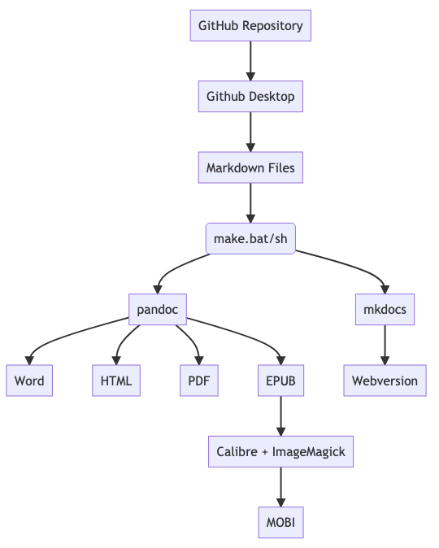

### 2.6.1 Структура каталогов руководства lernOS

Для того чтобы производственная цепочка lernOS работала, содержимое руководства должно быть сохранено в файловой папке со следующей структурой каталогов (пример руководства с немецкой и английской версиями, жирным шрифтом выделены имена папок и файлов, за ними - краткое описание):

```
lernos-repository
|- de # Немецкая языковая версия
   |- src # Файлы исходных текстов
      |- css
         |- extra.css # CSS файл для веб-версии
      |- images # Guide images
      |- 1-0-basics.md
      |- 2-0-learning-path.md
      |- 3-0-Appendix.md
      |- index.md # приветственная глава (= начальная страница)
   |- lernos-repository-en.docx # Версия Word
   |- lernos-repository-en.epub # Электронная версия книги (epub)
   |- lernos-repository-en.html # HTML-версия
   |- lernos-repository-en.mobi # Электронная версия книги (mobi)
   |- lernos-repository-en.pdf # PDF-версия
   |- make.bat # файл make (Windows)
   |- make.sh # make файл (Mac, Linux)
   |- metadata.yaml # метаданные для Pandoc
   |- mkdocs.yml # управляющие данные для веб-версии
|- en # та же структура, что и de
|- docs # веб-версии (по языкам)
   |- de
   |- en
|- README.md # Отображается на Github
```

- **en** - Содержание немецкой версии руководства
  - **src** - исходные тексты руководства в формате разметки
    - **css** - настройка цветов для веб-версии
    - **изображения** - Изображения путеводителя в форматах SVG и PNG
    - **1-Basics.md** - глава "Основы"
    - **2-learning-path.md** - глава "Путь обучения
    - **3-Annex.md** - глава "Приложение"
    - **index.md** - глава "О lernOS", должна называться index.md из-за веб-версии
  - **make.bat** - сердце производственной цепочки, [пакетный файл](https://de.wikipedia.org/wiki/BAT-Datei) (Windows), который производит все итоговые документы, запускается в проводнике файлов двойным щелчком. Примечание: для Mac и Linux вместо этого следует использовать файл оболочки (make.sh).
  - **metadata.yaml** - Метаданные для Pandoc (например, название, подзаголовок, автор(ы), версия и т.д.)
  - **mkdocs.yaml** - Настройки для генерации веб-версии с помощью mkdocs
- **документы**
  - **en** - немецкая веб-версия справочника
  - **en** - английская веб-версия руководства
- **en** - Содержание немецкой версии руководства
  - Структура идентична немецкой языковой версии

**Примечание:** в каталоге языковой версии также находятся все созданные документы (например, docx, epub, html, mobi, pdf).

**Примечание:** Для именования справочников для других языковых версий используются сокращения в соответствии с [ISO 639-1](https://de.wikipedia.org/wiki/Liste_der_ISO-639-1-Codes).

**Примечание:** В каталоге src руководство также может быть разделено на отдельные Markdown-файлы на уровне подразделов. Это полезно, например, если над содержанием одновременно работают несколько человек или если содержание должно быть комментируемым в веб-версии на уровне глав.

### 2.6.2 Производственная цепочка lernOS на Windows 10

Так называемый Makefile (make.bat) используется для создания целевых форматов из исходных текстов разметки. Если производственная цепочка на собственном компьютере настроена правильно, то двойной щелчок на Makefile (make.bat) приводит к автоматической генерации всех целевых форматов. В зависимости от размера и скорости вашего компьютера это может занять до нескольких минут. В производственной цепочке выполняются следующие этапы:

1. Удалите старые версии подготовленных документов.
2. Создайте версию в формате Word (.docx)
3. Создание HTML-версии (.html) (необработанный HTML, например, для копирования и вставки в CMS или ESN)
4. Создайте веб-версию (mkdocs с тематическим [материалом](https://squidfunk.github.io/mkdocs-material/), результат в папке docs)
5. Создать PDF-версию (.pdf)
6. Экспорт титульной страницы в виде графики из PDF (src/images/ebook-cover.jpg)
7. Создать версию электронной книги EPUB (.epub)
8. Конвертировать электронную книгу версии EPUB (.epub) в Mobipocket (.mobi)
9. Готов :-)

### 2.6.3 Идеи для расширения производственной цепочки lernOS

Как и справочники, производственная цепочка lernOS постоянно расширяется. Некоторые идеи для расширения:

- **Github Actions:** в настоящее время готовится автоматизированная производственная цепочка с [GitHub Actions](https://github.com/features/actions).
- **OneNote:** дополнительный выпуск версии руководств для OneNote (в настоящее время только в качестве сопроводительного документа, который приходится вести вручную).
- **Аудиокнига:** Создание аудиокниги с маркерами глав для прослушивания (например, с помощью [Balbolka](http://www.cross-plus-a.com/balabolka.htm)).

## 2.7 Набор инструментов для производственной цепочки

Производственная цепочка lernOS требует наличия некоторых инструментов на вашем собственном компьютере или в облаке:

1. **Редактор Markdown** - для редактирования содержания руководств, которые все написаны в формате Markdown (например, Typora, Atom или Mark Text).
2. **Github Desktop** - чтобы иметь возможность синхронизировать репозиторий руководства на GitHub с локальным компьютером.
3. **Pandoc** - для преобразования Markdown в целевые форматы производственной цепочки lernOS.
4. **LaTeX** - необходим Pandoc для создания файлов PDF.
5. **MkDocs** и **Материал для MkDocs** - для создания веб-версии руководства.
6. **ImageMagick** - для создания графического изображения титульной страницы руководства для вставки в версию электронной книги.
7. **Calibre** - для преобразования версии электронной книги, созданной Pandoc в формате epub, в формат mobi.

### 2.7.1 Typora

[Typora](https://typora.io/) - это текстовый редактор для редактирования [содержимого в формате Markdown](https://en.wikipedia.org/wiki/Markdown). Typora - это рекомендуемый редактор Markdown для lernOS, поскольку он доступен для всех платформ и отображает Markdown как настоящий WYSIWYG (What You See Is What You Get). В принципе, Markdown можно создавать и редактировать и с помощью простых текстовых редакторов, но вид WYSIWYG особенно удобен для новичков.

[figure not shown]

Скриншот Typora

### 2.7.2 Pandoc

[Pandoc](https://pandoc.org) - это текстовый конвертер на основе командной строки, который может преобразовывать Markdown в другие форматы. Пример преобразования Markdown в Microsoft Word:

```
pandoc document.md -o document.docx
```

Форматы, поддерживаемые Pandoc, включают:

- Asciidoc
- DokuWiki
- EPUB (электронная книга)
- HTML
- LaTeX
- Уценка
- MediaWiki
- Microsoft PowerPoint
- Microsoft Word (docx)
- OpenOffice/LibreOffice (odt)
- Reveal.js (онлайн-презентации)
- Текстиль (например, для Confluence)
- uvm.

### 2.7.3 Рабочий стол GitHub

[Github Desktop](https://desktop.github.com) - это клиент, который может синхронизировать репозитории GitHub с локальным компьютером. Это означает, например, что над содержимым Markdown можно работать локально и синхронизировать его с хранилищем по мере необходимости. Функциональность аналогична синхронизации файлов с Dropbox или OneDrive.

[figure not shown]

Скриншот рабочего стола Github

### 2.7.4 LaTeX & Co.

LaTeX - это пакет программ для преобразования текстовых документов, написанных в формате TeX, в такие форматы, как HTML или PDF. В производственной цепочке lernOS используется дистрибутив LaTeX [(MiKTeX](https://miktex.org) на Windows, [MacTeX](https://tug.org/mactex/https://tug.org/mactex/) на Mac) для создания PDF-файлов непосредственно с помощью pandoc. Для этого также требуется Ghostscript.

Шаблон pandoc LaTex [Eisvogel](https://github.com/Wandmalfarbe/pandoc-latex-template) используется в качестве шаблона для создания PDF руководств lernOS и адаптируется с помощью файла *metadata.yaml*. Для первого использования этого шаблона устанавливаются дополнительные расширения LaTeX.

### 2.7.5 MkDocs и материалы для MkDocs

[MkDocs](https://www.mkdocs.org/) - это генератор статических веб-сайтов, который создает отзывчивую веб-версию с навигацией, поиском, социальными ссылками и функцией комментирования. [Материал для MkDocs](https://squidfunk.github.io/mkdocs-material/) используется в качестве темы для веб-версии руководств lernOS.

[figure not shown]

Руководство по lernOS Веб-версия

Сервис Disqus используется для функции комментариев в конце каждой страницы веб-версии:

[figure not shown]

Комментарии с помощью Disqus Скриншот

### 2.7.6 Калибр

[Calibre](https://calibre-ebook.com) - это программное обеспечение для управления электронными книгами, которое используется для преобразования электронной книги версии EPUB в Mobipocket (mobi, например, для Kindle Reader и Kindle App). Чтобы извлечь изображение обложки в виде графика из PDF-версии справочника и масштабировать его до нужного размера для электронных книг, используется графический пакет [ImageMagick](https://www.imagemagick.org).

[figure not shown]

Скриншот Calibre

# 3 Путь обучения

Первый эскиз для 11 ката в учебном пути:

**До пит-стопа 1 - Техническая инфраструктура:**

- **Неделя 1 - Знакомство с Markdown:** Скачайте редактор Markdown (рекомендация Typora) и сделайте первые шаги в работе с синтаксисом Markdown. Преимущество Typora: вы уже можете экспортировать PDF, Word, HTML и т.д. без необходимости создания всей производственной цепочки (раннее чувство достижения).
- **Неделя 2 - Скачайте шаблон с GitHub:** из [репозитория lernos-template](https://github.com/cogneon/lernos-template) скачайте шаблон руководства в виде ZIP-файла (справа вверху: Code -> Download ZIP) и распакуйте локально. Ознакомьтесь со структурой каталогов и файлов.
- **Неделя 3 - Установите производственную цепочку:** Установите набор инструментов для производственной цепочки и запустите производственную цепочку. Внесите некоторые изменения в метаданные и содержание шаблона и создайте руководство.
- **Неделя 4 - Настройка синхронизации GitHub:** Создайте учетную запись GitHub, установите GitHub Desktop и синхронизируйте локальный каталог шаблонов с репозиторием GitHub. Понимать коммиты и разницу между ветками master/develop (см. также [Gitflow](https://www.atlassian.com/de/git/tutorials/comparing-workflows/gitflow-workflow)).

**До Pit Stop 2 - Структура Содержание и источники:**

- **Неделя 5 - Постановка цели:** какую цель обучения (образ мышления, набор навыков, инструментарий) должно достичь руководство для каких учащихся (целевой группы)? Получите обратную связь от представителей целевой группы.
- **Неделя 6 - Мозговой штурм Оглавление:** Проведите мозговой штурм, как можно структурировать оглавление по четырем стандартным главам (О lernOS, Основы, Путь обучения, Приложение). Это можно сделать, например, в форме MindMap (например, XMind), в которой вы можете очень гибко работать со структурами.
- **Неделя 7 - Оглавление на трех уровнях:** Определите структуру главы на трех (максимум четырех) уровнях. Для каждой главы здесь уже можно записать первые точки приложения усилий по содержанию.
- **Неделя 8 - Курирование источников:** Определите источники, на которые будут даны ссылки в базовой главе. Особое внимание следует уделить закреплению источника в теории и/или на практике (никаких шумих, причуд и т.д.), долгосрочной доступности (например, через институциональную поддержку) и открытому доступу.

**До ретроспективы - Содержание:**

- **Неделя 9 - Книжный спринт** В ходе [книжного спринта](https://de.wikipedia.org/wiki/Book_Sprint) продолжительностью от 1 до 5 дней создается основное содержание руководства. Цель состоит в том, чтобы версия 0.1 была доступна [как релиз](https://docs.github.com/en/github/administering-a-repository/managing-releases-in-a-repository) во всех целевых форматах на [GitHub](https://docs.github.com/en/github/administering-a-repository/managing-releases-in-a-repository) в конце книжного спринта, и чтобы целевая группа могла дать обратную связь (например, в виде проблем на GitHub или через комментируемую версию Word/Google Doc).
- **Неделя 10 - Обратная связь и редактирование:** Обратная связь с целевой группой включается в содержание. Тексты вычитываются, улучшаются тонкости, в результате чего появляется версия 0.2.
- **Неделя 11 - Go Live!:** Версия 0.2 публикуется на GitHub в виде очередного релиза и доводится до сведения целевой группы по соответствующим каналам. В идеале, некоторые Круги обучения опробуют руководство в следующем спринте и дадут обратную связь, на основе которой затем можно будет опубликовать версию 1.0.

# 4 Приложение

## 4.2 История изменений

[output not shown]

## 4.3 Глоссарий lernOS

**A**

- **Задание**
- **Рабочая среда**  
  Согласно DIN 33400, рабочая среда рабочей системы - это "пространственная среда, из которой на человека действуют прежде всего физические и химические, а также, помимо прочего, биологические (например, бактериологические) воздействия". Здесь люди и рабочее оборудование взаимодействуют в рабочем процессе на рабочем месте в условиях данной рабочей системы.

**C**

- **Агент перемен**
- **Управление изменениями**

**E**

- **Электронный портфель**  
  Электронный портфель - это персональная, структурированная и цифровая коллекция информации, которая поддерживает цели и процессы обучения на протяжении всей жизни, иллюстрируя приобретенные знания и навыки.

**F**

- **Формальная организация**
- **Формальное обучение**  
  Формальное обучение - это обучение, которое обычно проходит в учебном заведении, структурировано с точки зрения целей обучения, времени обучения или поддержки обучения и ведет к сертификации. Формальное обучение является целенаправленным с точки зрения учащегося (Европейская комиссия, 2001).
- **Лидерство** Лидерство - это деятельность по привлечению людей к постановке целей, созданию мотивирующих рамочных условий, поддержке процессов обучения и развития, а также поддержке достижения целей, когда это необходимо.
- **Менеджер**  
  Менеджер - это человек в организации, на которого возложены задачи по управлению персоналом.
- **Стиль лидерства**  
  Стиль лидерства относится к долгосрочному стабильному поведению лидера по отношению к сотрудникам, которое не зависит от ситуации. Классические стили руководства, согласно Левину, включают авторитарное руководство, демократическое руководство и руководство по принципу "свобода слова".

**G**

- **Приведение дел в порядок (GTD)**

**I**

- **Неформальная организация**
- **Неформальное**обучение  
  Неформальное обучение - это обучение, которое происходит в повседневной жизни, на работе, в кругу семьи или в свободное время. Он не структурирован с точки зрения целей обучения, времени обучения или поддержки обучения и обычно не ведет к сертификации. Неформальное обучение может быть целенаправленным, но в большинстве случаев оно является непреднамеренным и случайным (Европейская комиссия, 2001).
- **Инфраструктура**

**K**

- **Сотрудничество**  
  Сотрудничество - это совместная работа людей или групп людей (Википедия).
- **Коммуникация**  
  Коммуникация - это обмен или передача информации, которая может происходить различными способами (вербальными, невербальными) или разными способами (говорение, письмо) (Википедия).
- **Компетентность**  
  способность применять знания и навыки для достижения намеченных результатов (ISO 9001:2015).

**L**

- Обучение в**течение всей жизни**  
  Под обучением в течение всей жизни понимается любое обучение на протяжении всей жизни, которое служит для улучшения знаний, квалификации и компетенций и происходит в рамках личной, гражданской, социальной или связанной с работой перспективы (Европейская комиссия, 2001).
- **Обучение**  
  Обучение - это намеренное или случайное приобретение знаний и навыков. Обучение приводит к изменению поведения, мышления или чувств на основе нового опыта или понимания.
- **Обучающаяся организация**  
  Обучающаяся организация - это организация, которая обладает способностью генерировать, приобретать и распространять знания и изменять свое поведение на основе новых знаний и представлений.
- **lernOS**  
  lernOS - это открытая система для обучения в течение всей жизни и обучающих организаций. Она предоставляет открытые руководящие принципы для постоянного совершенствования обучения и управления знаниями на трех уровнях - индивидуальном, командном и организационном.
- **lernOS Canvas**
- **lernOS Wheel**
- **Путь обучения**
- **Обучающий спринт**
- **Круг обучения**  
  Группа из 4-5 человек, в которой участники помогают друг другу с помощью обратной связи, опыта, знаний и размышлений. Члены кружка встречаются еженедельно и следуют установленному распорядку, который структурирует процесс обучения и развития.

**M**

- **Менеджмент**  
  Менеджмент - это координация деятельности в организации для достижения целей организации.
- **Mindset**
- **Миссия**  
  Миссия описывает то, что организация делает или будет делать в своей повседневной деятельности (Модель бизнес-мотивации).

**O**

- **Цели и ключевые результаты (OKR)**
- **Организация**  
  Организация состоит из одного или нескольких человек (членов организации), объединенных общей целью и принявших формальную организационную структуру для ее достижения.

**P**

- **Проект**
- **Процесс**  
  набор взаимосвязанных или взаимодействующих видов деятельности, которые используют входы для получения запланированного результата (ISO 9001:2015).

**R**

- **Рулон**

**S**

- **Самоуправляемое обучение:**
- **Самоорганизация**
- **Чувства**
- **Набор навыков**
- **Sprint**
- **Стратегия**

**T**

- **Набор инструментов**
- **Истинный север**  
  "Истинный север" - это долгосрочная цель (также называемая видением), которая определяет годовые задачи и конкретные мероприятия по улучшению.

**V**

- **Видение**  
  Видение описывает будущее состояние организации и ее окружения, независимо от того, как оно будет достигнуто (Модель бизнес-мотивации).
- **VUCA** Акроним расшифровывается как волатильность, неопределенность, сложность и неоднозначность.

**W**

- **Знания**
- **Управление знаниями** Управление знаниями - это управление и проектирование обучающейся организации.
- **Working Out Loud**  
  Working Out Loud (WOL) - это способ работы, при котором статусы и результаты работы открыто видны (например, вики, открытое хранилище файлов), а о ходе работы открыто сообщается (например, блог, микроблог).
- **Программа обучения "Работа вслух"**  
  Программа обучения "Работа вслух" Джона Степпера - это 12-недельный курс обучения для начинающих, позволяющий освоить метод работы WOL.

**Z**

- **Цель**  
  Результат, который должен быть достигнут (ISO 9001:2015).